# Importing Libraries

```python
import pandas as pd
import numpy as np
import matplotlib.pyplot as plt
import seaborn as sns
import statsmodels.formula.api as smf
```

# Importing Dataset

```python
import os, types
import pandas as pd
from botocore.client import Config
import ibm_boto3

def __iter__(self): return 0

# @hidden_cell
# The following code accesses a file in your IBM Cloud Object Storage. It includes your credentials.
# You might want to remove those credentials before you share the notebook.
cos_client = ibm_boto3.client(service_name='s3',
    ibm_api_key_id='eASimw06bTq5Rjts5iIC_g7P6axTb0h5x736EBNISkSM',
    ibm_auth_endpoint="https://iam.cloud.ibm.com/oidc/token",
    config=Config(signature_version='oauth'),
    endpoint_url='https://s3.private.us.cloud-object-storage.appdomain.cloud')

bucket = 'mlbasedvehicleperformanceanalyser-donotdelete-pr-0isa20q1npyfgm'
object_key = 'car performance.csv'

body = cos_client.get_object(Bucket=bucket,Key=object_key)['Body']
# add missing __iter__ method, so pandas accepts body as file-like object
if not hasattr(body, "__iter__"): body.__iter__ = types.MethodType( __iter__, body )

dataset = pd.read_csv(body)
dataset.head(7)
```

|  | mpg | cylinders | displacement | horsepower | weight | acceleration | model year | origin | car name |
| --- | --- | --- | --- | --- | --- | --- | --- | --- | --- |
| 0 | 18.0 | 8 | 307.0 | 130 | 3504 | 12.0 | 70 | 1 | chevrolet chevelle malibu |
| 1 | 15.0 | 8 | 350.0 | 165 | 3693 | 11.5 | 70 | 1 | buick skylark 320 |
| 2 | 18.0 | 8 | 318.0 | 150 | 3436 | 11.0 | 70 | 1 | plymouth satellite |
| 3 | 16.0 | 8 | 304.0 | 150 | 3433 | 12.0 | 70 | 1 | amc rebel sst |
| 4 | 17.0 | 8 | 302.0 | 140 | 3449 | 10.5 | 70 | 1 | ford torino |
| 5 | 15.0 | 8 | 429.0 | 198 | 4341 | 10.0 | 70 | 1 | ford galaxie 500 |
| 6 | 14.0 | 8 | 454.0 | 220 | 4354 | 9.0 | 70 | 1 | chevrolet impala |

# Finding missing data

```python
dataset.isnull().any()
```

```
mpg             False
cylinders       False
displacement    False
horsepower      False
weight          False
acceleration    False
model year      False
origin          False
car name        False
dtype: bool
```

There are no null characters in the columns but there is a special character '?' in the 'horsepower' column. So we we replaced '?' with nan and replaced nan values with mean of the column.

```python
dataset['horsepower']=dataset['horsepower'].replace('?',np.nan)
```

```python
dataset['horsepower'].isnull().sum()
```

```
6
```

```python
dataset['horsepower']=dataset['horsepower'].astype('float64')
```

```python
dataset['horsepower'].fillna((dataset['horsepower'].mean()),inplace=True)
```

```python
dataset.isnull().any()
```

```
mpg             False
cylinders       False
displacement    False
horsepower      False
weight          False
acceleration    False
model year      False
origin          False
car name        False
dtype: bool
```

```python
dataset.info() #Pandas dataframe.info() function is used to get a quick overview of the dataset.
```

```
<class 'pandas.core.frame.DataFrame'>
RangeIndex: 398 entries, 0 to 397
Data columns (total 9 columns):
 #   Column        Non-Null Count  Dtype
---  ------        --------------  -----
 0   mpg           398 non-null    float64
 1   cylinders     398 non-null    int64
 2   displacement  398 non-null    float64
 3   horsepower    398 non-null    float64
 4   weight        398 non-null    int64
 5   acceleration  398 non-null    float64
 6   model year    398 non-null    int64
 7   origin        398 non-null    int64
 8   car name      398 non-null    object
dtypes: float64(4), int64(4), object(1)
memory usage: 28.1+ KB
```

```python
dataset.describe() #Pandas describe() is used to view some basic statistical details of a data frame or a series of numeric values.
```

|  | mpg | cylinders | displacement | horsepower | weight | acceleration | model year | origin |
| --- | --- | --- | --- | --- | --- | --- | --- | --- |
| count | 398.000000 | 398.000000 | 398.000000 | 398.000000 | 398.000000 | 398.000000 | 398.000000 | 398.000000 |
| mean | 23.514573 | 5.454774 | 193.425879 | 104.469388 | 2970.424623 | 15.568090 | 76.010050 | 1.572864 |
| std | 7.815984 | 1.701004 | 104.269838 | 38.199187 | 846.841774 | 2.757689 | 3.697627 | 0.802055 |
| min | 9.000000 | 3.000000 | 68.000000 | 46.000000 | 1613.000000 | 8.000000 | 70.000000 | 1.000000 |
| 25% | 17.500000 | 4.000000 | 104.250000 | 76.000000 | 2223.750000 | 13.825000 | 73.000000 | 1.000000 |
| 50% | 23.000000 | 4.000000 | 148.500000 | 95.000000 | 2803.500000 | 15.500000 | 76.000000 | 1.000000 |
| 75% | 29.000000 | 8.000000 | 262.000000 | 125.000000 | 3608.000000 | 17.175000 | 79.000000 | 2.000000 |
| max | 46.600000 | 8.000000 | 455.000000 | 230.000000 | 5140.000000 | 24.800000 | 82.000000 | 3.000000 |

There is no use with car name attribute so drop it

```python
dataset=dataset.drop('car name',axis=1) #dropping the unwanted column.
```

```python
corr_table=dataset.corr()#Pandas dataframe.corr() is used to find the pairwise correlation of all columns in the dataframe.
corr_table
```

|  | mpg | cylinders | displacement | horsepower | weight | acceleration | model year | origin |
| --- | --- | --- | --- | --- | --- | --- | --- | --- |
| mpg | 1.000000 | -0.775396 | -0.804203 | -0.771437 | -0.831741 | 0.420289 | 0.579267 | 0.563450 |
| cylinders | -0.775396 | 1.000000 | 0.950721 | 0.838939 | 0.896017 | -0.505419 | -0.348746 | -0.562543 |
| displacement | -0.804203 | 0.950721 | 1.000000 | 0.893646 | 0.932824 | -0.543684 | -0.370164 | -0.609409 |
| horsepower | -0.771437 | 0.838939 | 0.893646 | 1.000000 | 0.860574 | -0.684259 | -0.411651 | -0.453669 |
| weight | -0.831741 | 0.896017 | 0.932824 | 0.860574 | 1.000000 | -0.417457 | -0.306564 | -0.581024 |
| acceleration | 0.420289 | -0.505419 | -0.543684 | -0.684259 | -0.417457 | 1.000000 | 0.288137 | 0.205873 |
| model year | 0.579267 | -0.348746 | -0.370164 | -0.411651 | -0.306564 | 0.288137 | 1.000000 | 0.180662 |
| origin | 0.563450 | -0.562543 | -0.609409 | -0.453669 | -0.581024 | 0.205873 | 0.180662 | 1.000000 |

# Data Visualizations

Heatmap : which represents correlation between attributes

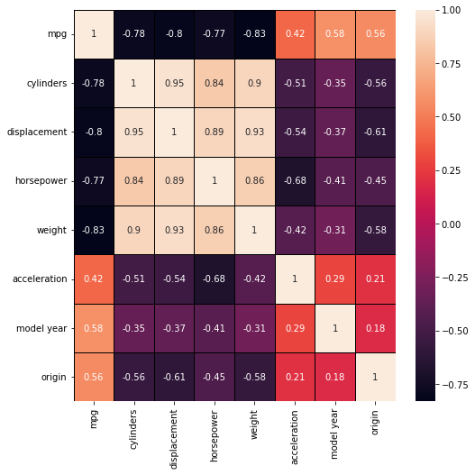

```python
sns.heatmap(dataset.corr(),annot=True,linecolor ='black', linewidths = 1)#Heatmap is a way to show some sort of matrix plot,annot is used for correlation.
fig=plt.gcf()
fig.set_size_inches(8,8)
```

Visualizations of each attributes w.r.t rest of all attributes

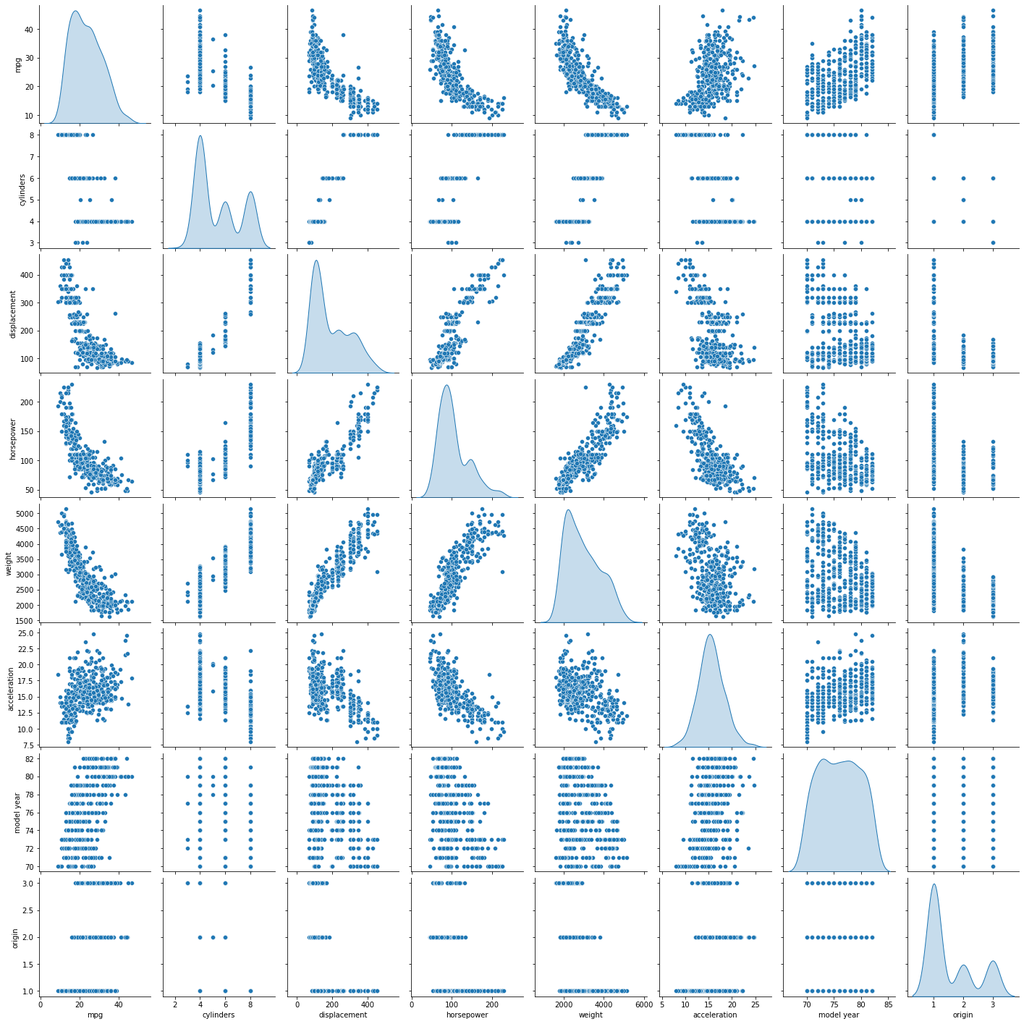

```python
sns.pairplot(dataset,diag_kind='kde') #pairplot represents pairwise relation across the entire dataframe.
plt.show()
```

Regression plots(regplot()) creates a regression line between 2 parameters and helps to visualize their linear relationships.

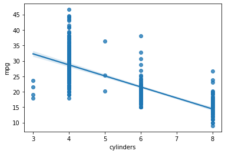

```python
sns.regplot(x="cylinders", y="mpg", data=dataset)
```

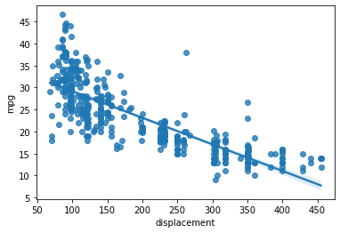

```python
sns.regplot(x="displacement", y="mpg", data=dataset)
```

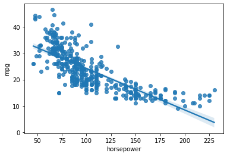

```python
sns.regplot(x="horsepower", y="mpg", data=dataset)
```

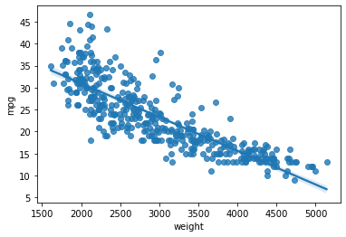

```python
sns.regplot(x="weight", y="mpg", data=dataset)
```

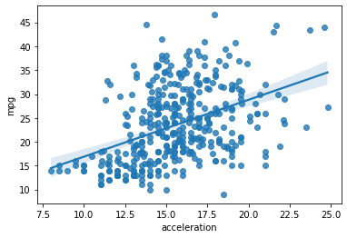

```python
sns.regplot(x="acceleration", y="mpg", data=dataset)
```

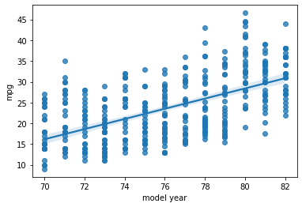

```python
sns.regplot(x="model year", y="mpg", data=dataset)
```

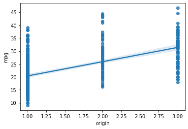

```python
sns.regplot(x="origin", y="mpg", data=dataset)
```

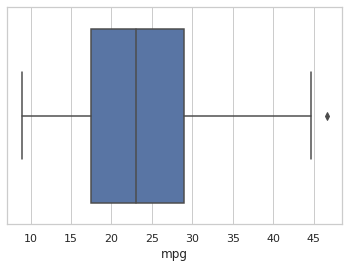

```python
sns.set(style="whitegrid")
sns.boxplot(x=dataset["mpg"])
```

# The P-value is the probability value that the correlation between these two variables is statistically significant.

Normally, we choose a significance level of 0.05, which means that we are 95% confident that the correlation between the variables is significant.

By convention, when the

- p-value is $<$ 0.001: we say there is strong evidence that the correlation is significant.
- the p-value is $<$ 0.05: there is moderate evidence that the correlation is significant.
- the p-value is $<$ 0.1: there is weak evidence that the correlation is significant.
- the p-value is $>$ 0.1: there is no evidence that the correlation is significant.

```python
from scipy import stats
```

### Cylinders vs mpg

Let's calculate the Pearson Correlation Coefficient and P-value of 'Cylinders' and 'mpg'.

```python
pearson_coef, p_value = stats.pearsonr(dataset['cylinders'], dataset['mpg'])
print("The Pearson Correlation Coefficient is", pearson_coef, " with a P-value of P =", p_value)
```

```
The Pearson Correlation Coefficient is -0.7753962854205542  with a P-value of P = 4.503992246177055e-81
```

##### Conclusion:

Since the p-value is $<$ 0.001, the correlation between cylinders and mpg is statistically significant, and the coefficient of ~ -0.775 shows that the relationship is negative and moderately strong.

### Displacement vs mpg

Let's calculate the Pearson Correlation Coefficient and P-value of 'Displacement' and 'mpg'.

```python
pearson_coef, p_value = stats.pearsonr(dataset['displacement'], dataset['mpg'])
print("The Pearson Correlation Coefficient is", pearson_coef, " with a P-value of P =", p_value)
```

```
The Pearson Correlation Coefficient is -0.8042028248058978  with a P-value of P = 1.6558889101930157e-91
```

### Horsepower vs mpg

Let's calculate the Pearson Correlation Coefficient and P-value of 'horsepower' and 'mpg'.

```python
pearson_coef, p_value = stats.pearsonr(dataset['horsepower'], dataset['mpg'])
print("The Pearson Correlation Coefficient is", pearson_coef, " with a P-value of P =", p_value)
```

```
The Pearson Correlation Coefficient is -0.7714371350025526  with a P-value of P = 9.255477533166725e-80
```

##### Conclusion:

Since the p-value is $<$ 0.001, the correlation between horsepower and mpg is statistically significant, and the coefficient of ~ -0.771 shows that the relationship is negative and moderately strong.

### Weight vs mpg

Let's calculate the Pearson Correlation Coefficient and P-value of 'weight' and 'mpg'.

```python
pearson_coef, p_value = stats.pearsonr(dataset['weight'], dataset['mpg'])
print("The Pearson Correlation Coefficient is", pearson_coef, " with a P-value of P =", p_value)
```

```
The Pearson Correlation Coefficient is -0.831740933244335  with a P-value of P = 2.9727995640500577e-103
```

##### Conclusion:

Since the p-value is $<$ 0.001, the correlation between weight and mpg is statistically significant, and the linear negative relationship is quite strong (~-0.831, close to -1)

### Acceleration vs mpg

Let's calculate the Pearson Correlation Coefficient and P-value of 'Acceleration' and 'mpg'.

```python
pearson_coef, p_value = stats.pearsonr(dataset['acceleration'], dataset['mpg'])
print("The Pearson Correlation Coefficient is", pearson_coef, " with a P-value of P =", p_value)
```

```
The Pearson Correlation Coefficient is 0.4202889121016507  with a P-value of P = 1.823091535078553e-18
```

### Model year vs mpg

Let's calculate the Pearson Correlation Coefficient and P-value of 'Model year' and 'mpg'.

```python
pearson_coef, p_value = stats.pearsonr(dataset['model year'], dataset['mpg'])
print("The Pearson Correlation Coefficient is", pearson_coef, " with a P-value of P =", p_value)
```

```
The Pearson Correlation Coefficient is 0.5792671330833096  with a P-value of P = 4.844935813365483e-37
```

##### Conclusion:

Since the p-value is $<$ 0.001, the correlation between model year and mpg is statistically significant, but the linear relationship is only moderate (~0.579).

### Origin vs mpg

Let's calculate the Pearson Correlation Coefficient and P-value of 'Origin' and 'mpg'.

```python
pearson_coef, p_value = stats.pearsonr(dataset['origin'], dataset['mpg'])
print("The Pearson Correlation Coefficient is", pearson_coef, " with a P-value of P =", p_value)
```

```
The Pearson Correlation Coefficient is 0.5634503597738431  with a P-value of P = 1.0114822102336483e-34
```

##### Conclusion:

Since the p-value is $<$ 0.001, the correlation between origin and mpg is statistically significant, but the linear relationship is only moderate (~0.563).

**Ordinary Least Squares** Statistics

```python
test=smf.ols('mpg~cylinders+displacement+horsepower+weight+acceleration+origin',dataset).fit()
test.summary()
```

OLS Regression Results

| Dep. Variable: | mpg | R-squared: | 0.717 |
| --- | --- | --- | --- |
| Model: | OLS | Adj. R-squared: | 0.713 |
| Method: | Least Squares | F-statistic: | 165.5 |
| Date: | Sat, 19 Nov 2022 | Prob (F-statistic): | 4.84e-104 |
| Time: | 19:13:46 | Log-Likelihood: | -1131.1 |
| No. Observations: | 398 | AIC: | 2276. |
| Df Residuals: | 391 | BIC: | 2304. |
| Df Model: | 6 |  |  |
| Covariance Type: | nonrobust |  |  |

|  | coef | std err | t | P>\|t\| | [0.025 | 0.975] |
| --- | --- | --- | --- | --- | --- | --- |
| Intercept | 42.7111 | 2.693 | 15.861 | 0.000 | 37.417 | 48.005 |
| cylinders | -0.5256 | 0.404 | -1.302 | 0.194 | -1.320 | 0.268 |
| displacement | 0.0106 | 0.009 | 1.133 | 0.258 | -0.008 | 0.029 |
| horsepower | -0.0529 | 0.016 | -3.277 | 0.001 | -0.085 | -0.021 |
| weight | -0.0051 | 0.001 | -6.441 | 0.000 | -0.007 | -0.004 |
| acceleration | 0.0043 | 0.120 | 0.036 | 0.972 | -0.232 | 0.241 |
| origin | 1.4269 | 0.345 | 4.136 | 0.000 | 0.749 | 2.105 |

| Omnibus: | 32.659 | Durbin-Watson: | 0.886 |
| --- | --- | --- | --- |
| Prob(Omnibus): | 0.000 | Jarque-Bera (JB): | 43.338 |
| Skew: | 0.624 | Prob(JB): | 3.88e-10 |
| Kurtosis: | 4.028 | Cond. No. | 3.99e+04 |

Notes:  
[1] Standard Errors assume that the covariance matrix of the errors is correctly specified.  
[2] The condition number is large, 3.99e+04. This might indicate that there are  
strong multicollinearity or other numerical problems.

Inference as in the above summary the p value of the accelaration is maximum(i.e 0.972) so we can remove the acc variable from the dataset

# Seperating into Dependent and Independent variables

**Independent variables**

```python
x=dataset[['cylinders','displacement','horsepower','weight','model year','origin']].values
x
```

```
array([[8.000e+00, 3.070e+02, 1.300e+02, 3.504e+03, 7.000e+01, 1.000e+00],
       [8.000e+00, 3.500e+02, 1.650e+02, 3.693e+03, 7.000e+01, 1.000e+00],
       [8.000e+00, 3.180e+02, 1.500e+02, 3.436e+03, 7.000e+01, 1.000e+00],
       ...,
       [4.000e+00, 1.350e+02, 8.400e+01, 2.295e+03, 8.200e+01, 1.000e+00],
       [4.000e+00, 1.200e+02, 7.900e+01, 2.625e+03, 8.200e+01, 1.000e+00],
       [4.000e+00, 1.190e+02, 8.200e+01, 2.720e+03, 8.200e+01, 1.000e+00]])
```

**Dependent variables**

```python
y=dataset.iloc[:,0:1].values
y
```

[output not shown]

[output cut: 343 more lines]

```
       [38. ],
       [32. ],
       [38. ],
       [25. ],
       [38. ],
       [26. ],
       [22. ],
       [32. ],
       [36. ],
       [27. ],
       [27. ],
       [44. ],
       [32. ],
       [28. ],
       [31. ]])
```

# Splitting into train and test data.

```python
from sklearn.model_selection import train_test_split
```

```python
x_train,x_test,y_train,y_test=train_test_split(x,y,test_size=0.1,random_state=0)
```

we are splitting as 90% train data and 10% test data

# Normalisation

```python
from sklearn.preprocessing import StandardScaler
sd = StandardScaler()
x_train = sd.fit_transform(x_train)
x_test = sd.fit_transform(x_test)
y_train = sd.fit_transform(y_train)
y_test = sd.fit_transform(y_test)

x_train
```

```
array([[ 1.46858608,  2.48230464,  2.97856512,  1.62455076, -1.61295698,
        -0.71873488],
       [ 1.46858608,  1.48729292,  1.55429873,  0.84358808, -1.61295698,
        -0.71873488],
       [-0.86550411, -0.70364636, -0.64684023, -0.36507278,  0.82235108,
        -0.71873488],
       ...,
       [-0.86550411, -1.21071964, -1.44960856, -1.31380657, -0.80118763,
         0.53032865],
       [ 0.30154098,  0.53055088, -0.12892518,  0.35799706, -1.3423672 ,
        -0.71873488],
       [-0.86550411, -1.00023639, -0.87990201, -0.89319732, -0.26000806,
         0.53032865]])
```

# decision tree regressor

```python
from sklearn.tree import DecisionTreeRegressor
dt=DecisionTreeRegressor(random_state=0,criterion="mae")
dt.fit(x_train,y_train)
```

```
DecisionTreeRegressor(criterion='mae', random_state=0)
```

```python
import pickle
pickle.dump(dt,open('decision_model.pkl','wb'))
```

```python
y_pred=dt.predict(x_test)
y_pred
```

```
array([-1.21248604,  0.40341575, -1.21248604, -0.56612532, -0.82466961,
        0.98514039,  2.07102639, -0.17830889, -1.08321389,  0.20950753,
        1.43759289,  2.74324153, -0.43685318,  0.33877968, -0.95394175,
        1.41173846,  0.41634296,  0.33877968, -0.82466961,  1.39881125,
       -0.95394175, -0.04903675, -0.24294497, -0.56612532,  1.33417517,
        0.20950753,  0.79123218,  0.98514039,  0.98514039, -0.43685318,
       -0.88930568,  1.50222896, -1.08321389,  1.04977646, -0.54027089,
       -0.39807154, -1.08321389, -0.95394175,  0.79123218, -1.60030246])
```

```python
y_test
```

```
array([[-1.29002284],
       [ 0.03307751],
       [-1.41030469],
       [-0.44804989],
       [-0.80889544],
       [ 1.23589601],
       [ 1.12764234],
       [-0.56833174],
       [-1.16974099],
       [-0.14734527],
       [ 1.94555892],
       [ 1.50051608],
       [-0.80889544],
       [-0.20748619],
       [-1.10960007],
       [ 1.3200933 ],
       [ 0.75476861],
       [ 0.27364121],
       [-0.80889544],
       [ 1.51254426],
       [-1.10960007],
       [-0.20748619],
       [-0.08720434],
       [-0.80889544],
       [ 1.17575508],
       [ 0.08119025],
       [ 1.36820604],
       [ 1.11561416],
       [ 0.63448676],
       [-1.04945914],
       [-0.73672633],
       [ 1.47645971],
       [-1.16974099],
       [ 1.05547323],
       [-0.2796553 ],
       [-0.08720434],
       [-0.68861359],
       [-0.94120548],
       [ 0.86302227],
       [-1.53058654]])
```

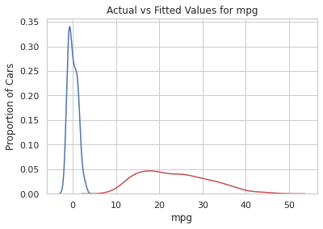

```python
ax1 = sns.distplot(dataset['mpg'], hist=False, color="r", label="Actual Value")
sns.distplot(y_pred, hist=False, color="b", label="Fitted Values" , ax=ax1)


plt.title('Actual vs Fitted Values for mpg')
plt.xlabel('mpg')
plt.ylabel('Proportion of Cars')

plt.show()
plt.close()
```

**R-squared**

R-squared is a statistical measure of how close the data are to the fitted regression line. It is also known as the coefficient of determination, or the coefficient of multiple determination for multiple regression.

R-squared = Explained variation / Total variation

**Mean Squared Error (MSE)**

The Mean Squared Error measures the average of the squares of errors, that is, the difference between actual value (y) and the estimated value (ŷ).

```python
from sklearn.metrics import r2_score,mean_squared_error
```

```python
r2_score(y_test,y_pred)
```

```
0.8693935947768933
```

```python
mean_squared_error(y_test,y_pred)
```

```
0.1306064052231067
```

```python
np.sqrt(mean_squared_error(y_test,y_pred))
```

```
0.36139508190221226
```

# random forest regressor

```python
from sklearn.ensemble import RandomForestRegressor
```

```python
rf= RandomForestRegressor(n_estimators=10,random_state=0,criterion='mae')
rf.fit(x_train,y_train)
```

```
RandomForestRegressor(criterion='mae', n_estimators=10, random_state=0)
```

```python
y_pred2=rf.predict(x_test)
y_pred2
```

```
array([-1.22541325,  0.04145375, -1.27712211, -0.21321237, -0.73417911,
        0.94635875,  1.42983656,  0.05438096, -1.08321389,  0.09057716,
        1.36778593,  1.89133811, -0.52734368,  0.26380183, -0.95394175,
        1.04460558,  0.5818113 ,  0.23406924, -0.86991486,  1.10794893,
       -0.97333257,  0.19140943,  0.03757558, -0.29982471,  0.86879546,
       -0.02318232,  1.1066562 ,  1.07563089,  1.09760715, -0.87767119,
       -0.39677881,  1.0278002 , -0.82596233,  0.97221318, -0.18735794,
       -0.03610954, -0.59844336, -0.92808732,  1.28375904, -1.47103032])
```

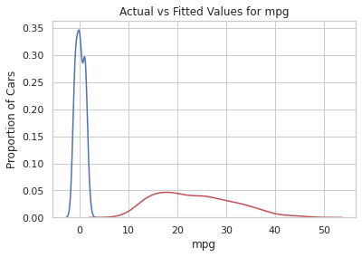

```python
ax1 = sns.distplot(dataset['mpg'], hist=False, color="r", label="Actual Value")
sns.distplot(y_pred2, hist=False, color="b", label="Fitted Values" , ax=ax1)


plt.title('Actual vs Fitted Values for mpg')
plt.xlabel('mpg')
plt.ylabel('Proportion of Cars')

plt.show()
plt.close()
```

```python
from sklearn.metrics import r2_score,mean_squared_error
```

```python
r2_score(y_test,y_pred2)
```

```
0.9172449209441422
```

```python
mean_squared_error(y_test,y_pred2)
```

```
0.08275507905585772
```

```python
np.sqrt(mean_squared_error(y_test,y_pred2))
```

```
0.28767182527292745
```

# linear regression

```python
from sklearn.linear_model import LinearRegression
mr=LinearRegression()
mr.fit(x_train,y_train)
```

```
LinearRegression()
```

```python
y_pred3=mr.predict(x_test)
y_pred3
```

```
array([[-1.48354417],
       [ 0.02018821],
       [-1.68903988],
       [-0.42532853],
       [-0.85893857],
       [ 0.68603096],
       [ 1.21891251],
       [-0.13204094],
       [-1.23799478],
       [ 0.3208166 ],
       [ 1.05032664],
       [ 1.27944186],
       [-0.35801006],
       [ 0.22377607],
       [-1.07318175],
       [ 0.84489227],
       [ 0.55090001],
       [ 0.59162161],
       [-0.86938749],
       [ 0.90060746],
       [-1.19252105],
       [ 0.06263748],
       [ 0.34334107],
       [-0.49842421],
       [ 0.7257113 ],
       [ 0.5306685 ],
       [ 0.90224828],
       [ 0.75809371],
       [ 0.75230078],
       [-0.81562435],
       [-0.51790152],
       [ 0.92628973],
       [-0.41719037],
       [ 1.02755713],
       [-0.05714634],
       [ 0.26677556],
       [-0.37496781],
       [-1.01152038],
       [ 1.04592662],
       [-2.01630218]])
```

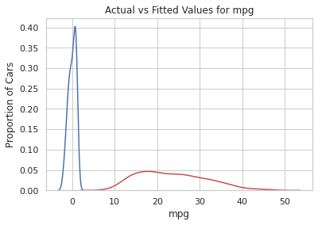

```python
ax1 = sns.distplot(dataset['mpg'], hist=False, color="r", label="Actual Value")
sns.distplot(y_pred3, hist=False, color="b", label="Fitted Values" , ax=ax1)


plt.title('Actual vs Fitted Values for mpg')
plt.xlabel('mpg')
plt.ylabel('Proportion of Cars')

plt.show()
plt.close()
```

```python
from sklearn.metrics import r2_score,mean_squared_error
r2_score(y_test,y_pred3)
```

```
0.8631101197005312
```

```python
mean_squared_error(y_test,y_pred3)
```

```
0.13688988029946877
```

```python
np.sqrt(mean_squared_error(y_test,y_pred3))
```

```
0.3699863244762822
```

**Conclusion:**

When comparing models, the model with the higher R-squared value is a better fit for the data.

When comparing models, the model with the smallest MSE value is a better fit for the data.

```python
from ibm_watson_machine_learning import APIClient
wml_credentials = {
                    "url": "https://us-south.ml.cloud.ibm.com",
                    "apikey":"c0AaDte5MvL14V1NwKhlSgGHH34bvKX_VN8iFiLyAPQ5"

                   }
client = APIClient(wml_credentials)
```

```python
def guid_from_space_name(client, space_name):
    space = client.spaces.get_details()
    return(next(item for item in space['resources'] if item['entity']["name"] == space_name)['metadata']['id'])

space_uid = guid_from_space_name(client, 'models')
print("Space UID = " + space_uid)
```

```
Space UID = ec50822e-7eed-4693-abad-e892683a6177
```

```python
client.set.default_space(space_uid)
```

```
'SUCCESS'
```

```python
client.software_specifications.list()
```

[output not shown]

```python
software_spec_uid = client.software_specifications.get_uid_by_name("default_py3.6")
software_spec_uid
```

```
'0062b8c9-8b7d-44a0-a9b9-46c416adcbd9'
```

```python
!pip install -U pyspark==2.1.2
#  model_details = client.repository.store_model(model=rf,meta_props={
#      client.repository.ModelMetaNames.NAME:"car-performance",
#       client.repository.ModelMetaNames.TYPE:"scikit-learn_1.0",
#     client.repository.ModelMetaNames.SOFTWARE_SPEC_UID:software_spec_uid }
#  )

# model_id = client.repository.get_model_uid(model_details)
```

[output not shown]

```python
# metadata = {
#     client.repository.ModelMetaNames.NAME: 'ML-Model',
#     client.repository.ModelMetaNames.TYPE: 'scikit-learn_0.22',
#     client.repository.ModelMetaNames.SOFTWARE_SPEC_UID: software_spec_uid
# }

# published_model = client.repository.store_model(
#     model=rf,
#     meta_props=metadata,
#     training_data=x_train,
#     training_target=y_train)
```

```python
sofware_spec_uid = client.software_specifications.get_id_by_name("runtime-22.1-py3.9")
metadata = {
client.repository.ModelMetaNames.NAME: 'Gradient',
client.repository.ModelMetaNames.TYPE: 'scikit-learn_1.0',
client.repository.ModelMetaNames.SOFTWARE_SPEC_UID: sofware_spec_uid
}
published_model = client.repository.store_model(
model=rf,
meta_props=metadata)
```

```python
!wget https://https://raw.githubusercontent.com/IBM/monitor-wml-model-with with-watson-openscale/master/data/additional_feedback_data.json
```

[output not shown]

```python
# best_model = 'rf'
# MODEL_NAME="Car-Performance"
# DEPLOYMENT_NAME = "Car-Performance-Deployment"
# BEST_MODEL = best_model

published_model
```

```
{'entity': {'hybrid_pipeline_software_specs': [],
  'software_spec': {'id': '12b83a17-24d8-5082-900f-0ab31fbfd3cb',
   'name': 'runtime-22.1-py3.9'},
  'type': 'scikit-learn_1.0'},
 'metadata': {'created_at': '2022-11-19T19:14:13.167Z',
  'id': 'ba031043-c69e-4719-b9ec-950f75bbb7ad',
  'modified_at': '2022-11-19T19:14:15.659Z',
  'name': 'Gradient',
  'owner': 'IBMid-6620041XAB',
  'resource_key': 'f53c7996-2147-46c8-a43c-6f7fbc7cdb55',
  'space_id': 'ec50822e-7eed-4693-abad-e892683a6177'},
 'system': {'warnings': []}}
```

```python
# model_props={
#     client.repository.ModelMetaNames.NAME:"models".format(rf)
# }
```

```python
#  published_model_details=client.repository.store_model(model=BEST_MODEL,meta_props=model_props,training_data=x_train,training_target=y_train)
# stored_model_details = client.repository.create_version(trained_model_guid, model_uid="MODELID" ,meta_props=metadata)
```

```python
# model_id
```

```python
x_train[0]
```

[output not shown]

```python
rf.predict([[1.46858608,  2.48230464,  2.97856512,  1.62455076, -1.61295698,
       -0.71873488]])
```

[output not shown]